# ICMBio/CENAP Programa Monitora - Análise de tendências populacionais de mamíferos terrestres de médio e grande porte na Resex Tapajós-Arapiuns, 2015-2019

Elildo Carvalho Jr

Janeiro de 2022

## Introdução

Este relatório analisa resultados do Programa Monitora, Subprograma Terrestre, Componente Florestal Global, Alvo Mamíferos terrestres de médio e grande porte, protocolo básico, na **Reserva Extrativista Tapajós-Arapiuns**, 2015 a 2019. O trabalho teve como objetivo descrever a variação anual nas populações de espécies selecionadas, e identificar se elas estão estáveis ou se há tendências significativas de declínio ou aumento populacional.

Ressalta-se que o relatório visa somente descrever os padrões observados. Interpretações sobre suas possíveis causas devem ser debatidas entre comunidades locais, gestores e pesquisadores.

## Métodos

Foram analisados dados do protocolo básico coletados na Resex Tapajós-Arapiuns entre os anos de 2015 e 2019[^1]. O protocolo utiliza o método de transecções lineares (Peres, 1999; Peres and Cunha, 2011). Resumidamente, dois observadores percorrem as transecções a uma velocidade constante e registram, para cada avistamento de animais dos grupos-alvo, a espécie, o número de indivíduos e a distância perperndicular entre o primeiro indivíduo avistado e o centro da trilha. Cada UC deve ter pelo menos três transectos de 5 km e o esforço anual mínimo, combinando todos os transectos, deve ser de 150 km percorridos (Nobre et al., 2015).

Os dados do protocolo básico são utilizados para estimar índices populacionais para as espécies-alvo, como taxa de encontro (indivíduos ou grupos avistados a cada 10 km percorridos) ou densidade (individuos ou grupos por km<sup>2</sup>). O monitoramento desses índices pode viabilizar a detecção de perturbações ambientais, a emissão de alertas sobre declínios populacionais e a avaliação do sucesso de ações de manejo (Field et al., 2007; Legg and Nagy, 2006).

No presente trabalho, o índice populacional escolhido foi a *taxa de encontro de grupos* (grupos/10 km):
$$\textit{Taxa de encontro}=\frac{\textit{Número de grupos observados}}{\textit{Km percorridos} }\times 10$$

A taxa de encontro foi calculada para cada ano agregando os dados de todos os transectos. Ressalta-se que o índice tem limitações: ele não leva em conta variações temporais no tamanho dos grupos, nas distâncias perpendiculares dos avistamentos, ou na detectabilidade dos grupos ao longo do tempo. Essas limitações afetam a precisão e acurácia do índice populacional, e limitam o poder da análise em detectar declínios populacionais. Em relatórios futuros, índices que levem em conta esses fatores serão desenvolvidos e avaliados.

- *r* < 0, a população está declinando
- *r* = 0, a população está estável
- *r* > 0, a população está aumentando

A estimativa de *r* sempre envolve incerteza, por isso o intervalo de confiança da estimativa também precisa ser verificado. Intervalos de confiança muito amplos implicam em muita incerteza sobre o que está de fato acontecendo com a população. Ainda assim, o modelo adotado permite estimar a probabilidade de uma população estar declinando ou aumentando (Kéry and Schaub, 2012: 37). Isso é especiamente relevante no contexto do monitoramento da biodiversidade, onde alertas antecipados de declínios populacionais são necessários. Mesmo sem ter certeza absoluta, os gestores podem tomar decisões com base nas probabilidades estimadas, seguindo o princípio da precaução.

Além da estimativa de *r*, o modelo gera uma estimativa *suavizada* do índice populacional a cada ano. Essa estimativa representa a trajetória mais provável da população no período analisado, e foi utilizada para elaborar gráficos representando as tendências populacionais durante o monitoramento, incluindo medidas da incerteza associada à estimativa. No entanto, ressalta-se que essas estimativas suavizadas não corrigem erros decorrentes de variações na taxa de detecção (Kéry and Schaub, 2012). Para várias espécies, pode ser viável corrigir erros de detecção a partir das distâncias perpendiculares (Buckland et al., 2001) e ajustar o índice populacional incorporando dados sobre o tamanho dos grupos. Isso permitirá estimativas mais precisas das tendências populacionais e será avaliado em relatórios futuros.

## Resultados e discussão

A tabela 1 apresenta o esforço amostral e o número total de registros obtidos na Resex Tapajós-Arapiuns desde o início do monitoramento. Foram registradas 40 especies de mamiferos de médio e grande porte (Tabela 2), sendo que seis delas atenderam ao critério mínimo para inclusão nas análises: *Alouatta nigerrima, Dasyprocta croconota, Mazama sp., Mico humeralifer, Nasua nasua* e *Sapajus apella*.

A maioria das espécies apresentou taxa de crescimento positiva, mas os intervalos de confiança foram muito amplos e sempre incluíramo zero, ou seja, as tendências não foram estatisticamente significativas (Tabela 3, Figuras 1 a 6).

Em termos de probabilidade de estar aumentando ou declinando, quatro espécies apresentaram alta (>75%) probabilidade de estarem aumentando: *Mazama sp., Mico humeralifer, Nasua nasua* e *Sapajus apella*. Nenhuma apresentou alta (>75%) probabilidade de estar declinando.

A continuação do monitoramento por um período mais longo pode revelar a consistência das tendências populacionais observadas (Fairweather, 1991; Field et al., 2007). Além disso, análises mais refinadas, incorporando as informações sobre o tamanho dos grupos, distâncias perpendiculares dos avistamentos, e variação entre as trilhas, podem ter mais poder estatístico para detectar tendências, permitindo conclusões mais robustas. Isso será avaliado em relatórios futuros. Independente disso, os resultados obtidos podem contribuir para a gestão e tomada de decisões no manejo da biodiversidade local.

Em resumo, foram avaliadas as tendências populacionais de seis espécies de mamíferos de médio e grande porte na Resex Tapajós-Arapiuns entre os anos de 2015 e 2019. A maioria das populações apresentou leve tendência de crescimento, mas em nenhum caso essa tendência foi significativa. Para uma interpretação adequada desses padrões, recomenda-se que esses resultados sejam debatidos entre comunidades locais, gestores e pesquisadores.

Esforço anual e número de registros de mamíferos obtidos pelo protocolo básico do Programa Monitora na Resex Tapajós-Arapiuns, 2015-2019

| ano | transectos | esforco | registros |
| --- | --- | --- | --- |
| 2014 | 2 | 50 | 37 |
| 2015 | 8 | 265 | 206 |
| 2016 | 7 | 315 | 368 |
| 2017 | 8 | 485 | 582 |
| 2018 | 8 | 370 | 443 |
| 2019 | 8 | 385 | 500 |

Espécies, número de grupos (n) e taxa média de avistamento (grupos/10km) registrados pelo protocolo básico na Resex Tapajós-Arapiuns, 2015 a 2019

| binomial | n | grupos_10km |
| --- | --- | --- |
| Dasyprocta croconota | 999 | 5.34 |
| Sapajus apella | 296 | 1.58 |
| Mazama sp. | 184 | 0.98 |
| Nasua nasua | 90 | 0.48 |
| Alouatta nigerrima | 82 | 0.44 |
| Mico humeralifer | 72 | 0.39 |
| Pecari tajacu | 48 | 0.26 |
| Chiropotes albinasus | 48 | 0.26 |
| Cebus unicolor | 46 | 0.25 |
| Pithecia irrorata | 46 | 0.25 |
| Callicebus hoffmannsi | 38 | 0.20 |
| Urosciurus spadiceus | 21 | 0.11 |
| Myoprocta pratti | 21 | 0.11 |
| Guerlinguetus aestuans | 19 | 0.10 |
| Tayassu pecari | 14 | 0.07 |
| Eira barbara | 12 | 0.06 |
| Bradypus variegatus | 12 | 0.06 |
| Myrmecophaga tridactyla | 9 | 0.05 |
| Tamandua tetradactyla | 8 | 0.04 |
| Leopardus sp. | 7 | 0.04 |
| Galictis vittata | 6 | 0.03 |
| Saimiri ustus | 6 | 0.03 |
| Choloepus didactylus | 5 | 0.03 |
| Panthera onca | 5 | 0.03 |
| Dasypus sp. | 5 | 0.03 |
| Dasypus novemcinctus | 5 | 0.03 |
| Tapirus terrestris | 4 | 0.02 |
| Didelphis marsupialis | 4 | 0.02 |
| Puma concolor | 4 | 0.02 |
| Aotus nigriceps | 3 | 0.02 |
| Coendou prehensilis | 3 | 0.02 |
| Cuniculus paca | 3 | 0.02 |
| Cerdocyon thous | 2 | 0.01 |
| Cabassous unicinctus | 2 | 0.01 |
| Sciurillus pusillus | 2 | 0.01 |
| Ateles chamek | 1 | 0.01 |
| Lontra longicaudis | 1 | 0.01 |
| Cyclopes didactylus | 1 | 0.01 |
| Puma yagouaroundi | 1 | 0.01 |
| Callicebus sp. | 1 | 0.01 |

Taxa de crescimento populacional (r), intervalo de confiança (IC) e probabilidade de a população estar em declínio ou aumentando, Resex Tapajós-Arapiuns, 2015-2019

| Especie | r | IC | Prob. declinio | Prob. aumento |
| --- | --- | --- | --- | --- |
| Mazama sp. | 0.14 | -0.39 a 0.7 | 23% | 77% |
| Dasyprocta croconota | 0.04 | -0.48 a 0.57 | 40% | 60% |
| Sapajus apella | 0.23 | -0.3 a 0.76 | 14% | 86% |
| Mico humeralifer | 0.28 | -0.37 a 0.92 | 16% | 84% |
| Nasua nasua | 0.26 | -0.25 a 0.77 | 10% | 90% |
| Alouatta nigerrima | -0.03 | -0.63 a 0.56 | 57% | 43% |

## Literatura citada

Buckland, S.T., Anderson, D.R., Burnham, K.P., Laake, J.L., Borchers, D.L., Thomas, L., 2001. Introduction to distance sampling: Estimating abundance of biological populations. Oxford University Press, Oxford, UK.

Fairweather, P.G., 1991. Statistical power and design requirements for environmental monitoring. Marine and Freshwater Research 42, 555–567. https://doi.org/10.1071/MF9910555

Field, S.A., O’Connor, P.J., Tyre, A.J., Possingham, H.P., 2007. Making monitoring meaningful. Austral Ecology 32, 485–491. https://doi.org/10.1111/j.1442-9993.2007.01715.x

Gelman, A., Shirley, K., 2011. Inference from simulations and monitoring convergence, in: Brooks, S., Gelman, A., Jones, G.L., Meng, X.-L. (Eds.), Handbook of Markov Chain Monte Carlo. Chapman; Hall/CRC, Boca Raton, pp. 163–174. https://doi.org/10.1201/b10905-7

Kéry, M., Schaub, M., 2012. Bayesian Population Analysis Using WinBUGS. Academic Press. https://doi.org/10.1016/C2010-0-68368-4

Legg, C.J., Nagy, L., 2006. Why most conservation monitoring is, but need not be, a waste of time. Journal of Environmental Management 78, 194–199. https://doi.org/10.1016/j.jenvman.2005.04.016

Nobre, R. de A., Kinouchi, M.R., Constantino, P.A.L., Pereira, R.C., Uehara-Prado, M., 2015. Monitoramento da biodiversidade: roteiro metodológico de aplicação. ICMBio, Brasilia, DF.

Peres, C.A., 1999. General Guidelines for Standardizing Line-Transect Surveys of Tropical Forest Primates. Neotropical Primates 7, 11–16.

Peres, C.A., Cunha, A.A., 2011. Manual para censo e monitoramento de vertebra- dos de médio e grande porte por transecção linear em florestas tropicais. Wildife Conservation Society, Ministério do Meio Ambiente e ICMBio, Brasilia, DF.

Plummer, M., 2015. JAGS Version 4.0.0 user manual 0–41.

Su, Y., Yajima, M., 2012. R2jags: A Package for Running jags from R.

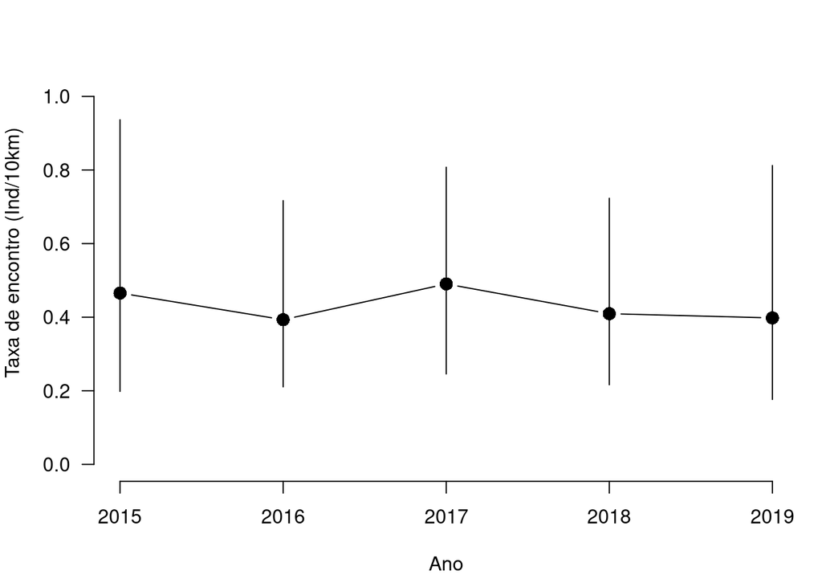

Taxa de encontro anual para *Alouatta nigerrima* na Resex Tapajós-Arapiuns. As barras verticais indicam a incerteza associada à estimativa (IC de 95%)

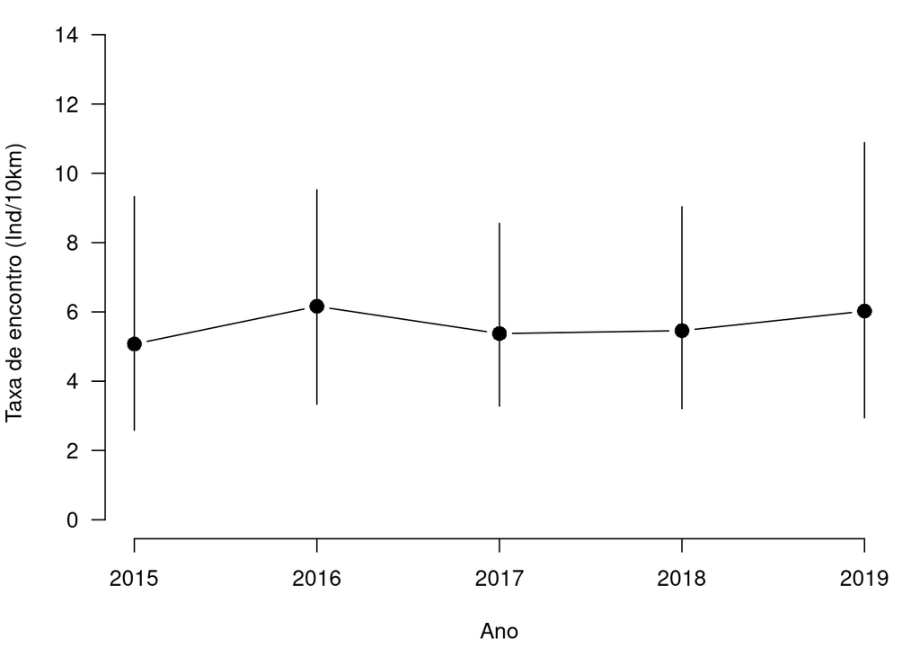

Taxa de encontro anual para *Dasyprocta croconota* na Resex Tapajós-Arapiuns. As barras verticais indicam a incerteza associada à estimativa (IC de 95%)

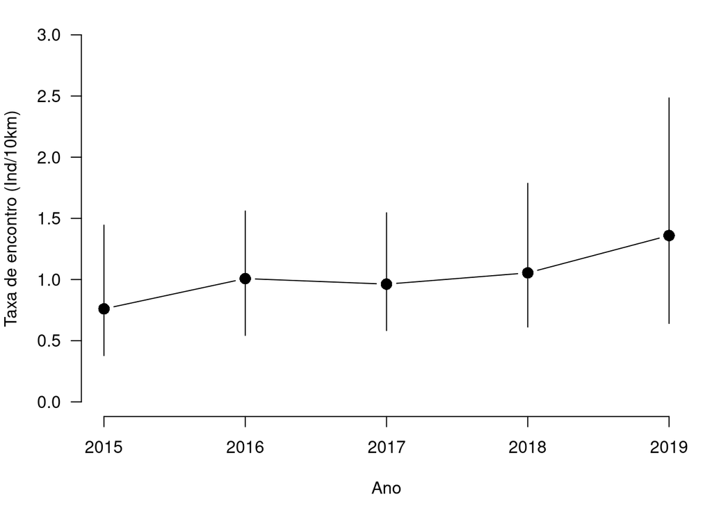

Taxa de encontro anual para *Mazama spp.* na Resex Tapajós-Arapiuns. As barras verticais indicam a incerteza associada à estimativa (IC de 95%)

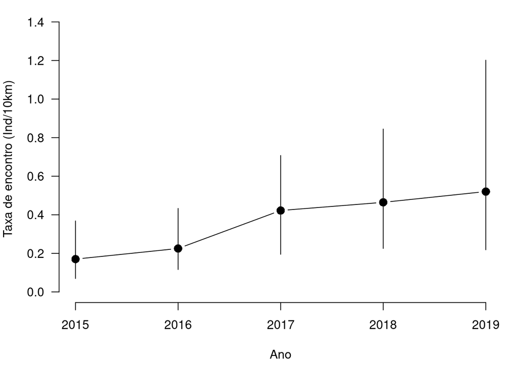

Taxa de encontro anual para *Mico humeralifer* na Resex Tapajós-Arapiuns. As barras verticais indicam a incerteza associada à estimativa (IC de 95%)

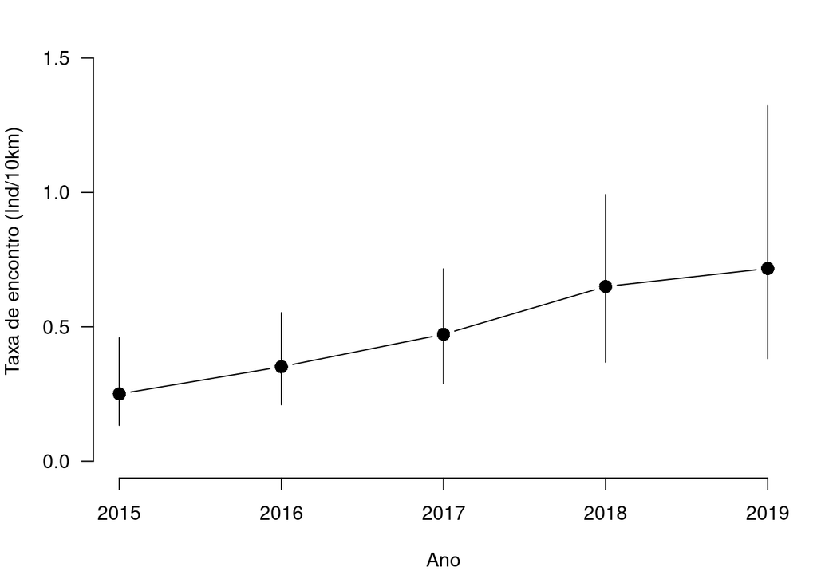

Taxa de encontro anual para *Nasua nasua* na Resex Tapajós-Arapiuns. As barras verticais indicam a incerteza associada à estimativa (IC de 95%)

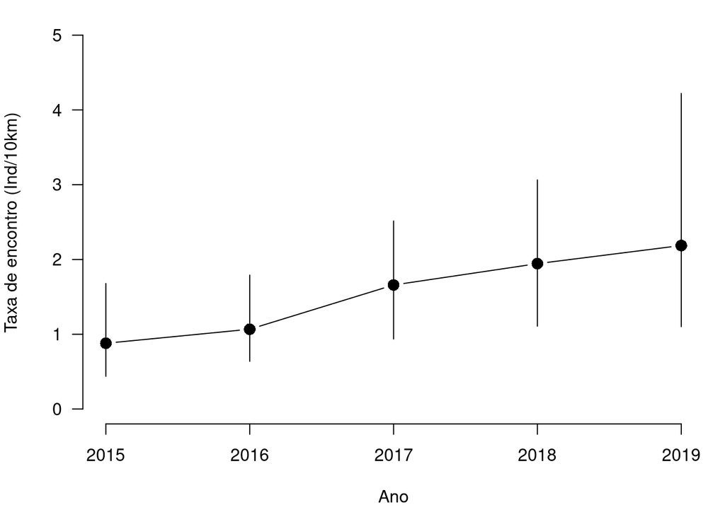

Taxa de encontro anual para *Sapajus apella* na Resex Tapajós-Arapiuns. As barras verticais indicam a incerteza associada à estimativa (IC de 95%)

# Anexo 1: Descrição do modelo populacional

Foi ajustado um modelo estocástico de dinâmica populacional aos dados. Esse modelo particiona a variação nos dados observados em dois componentes: um componente associado ao *processo ecológico* (variações aleatórias na taxa de crescimento populacional) e um componente associado ao *processo de observação* (variações devido a erros aleatórios nas estimativas anuais de abundância).

## *Processo ecológico*

No modelo, o tamanho da população no ano *t+1* (*N<sub>t+1</sub>*) depende do tamanho da população no ano anterior (*N<sub>t</sub>*) e da taxa de crescimento populacional (*r<sub>t</sub>*):

$$log(N_t+_1) = log(N_t) + r_t$$

As taxas anuais de crescimento populacional *r<sub>t</sub>* são vistas como realizações de um processo estocástico com distribuição normal centrada na taxa de crescimento médio *r* para todo o período e variância correspondente à estocasticidade ambiental (Kéry and Schaub, 2012).

## *Processo de observação*

As observações no ano *t* (*y<sub>t</sub>*) estão sujeitas a erro estocástico ($\epsilon$) com distribuição normal centrada no zero:

$$y_t = N_t + \varepsilon$$

## *Premissas*

No presente trabalho, o índice populacional utilizado foi a *taxa de encontro de grupos* (grupos/10 km). A validade do modelo depende das seguintes premissas:

1. o índice populacional segue trajetória paralela ao tamanho real da população.
2. a probabilidade de detecção permanece constante ao longo do tempo.
3. o tamanho médio dos grupos permanece constante ao longo do tempo.
4. as distâncias perpendiculares dos avistamentos permanecem constantes ao longo do tempo.

A validade de pelo menos algumas dessas premissas pode ser testada com os próprios dados (e.g., constância no tamanho de grupo e nas distâncias perpendiculares). Isso será feito em relatórios futuros. Por ora, assume-se que elas sejam válidas.

*Observação:* Antes das análises, as taxas de encontro = 0 foram substituídas por 0.001. Isso foi necessário porque, no modelo, se a população é zero no ano *t* ela permanece nesse estado em todos os anos subsequentes. Isso não é realista já que (i) um índice populacional zero não implica necessariamente numa população zero, (ii) mesmo em caso de população zero há a possibilidade de recolonização.

## *Implementação*

O modelo foi implementado numa abordagem Bayesiana, seguindo as especificações de (Kéry and Schaub, 2012: 126-130) no JAGS (Plummer, 2015) usando o pacote R2jags (Su and Yajima, 2012). Foram executadas três Cadeias de Markov e Monte Carlo (MCMC) com 25000 iterações, *burn-in* de 1000 e *thinning rate* de 3. A convergência dos parâmetros foi avaliada pelo diagnóstico de Gelman-Rubin (Gelman and Shirley, 2011). Todos os dados e códigos utilizados estão disponiveis no repositório https://github.com/ICMBio-CENAP/Programa-Monitora-Florestal-Global.

## Literatura citada

Buckland, S.T., Anderson, D.R., Burnham, K.P., Laake, J.L., Borchers, D.L., Thomas, L., 2001. Introduction to distance sampling: Estimating abundance of biological populations. Oxford University Press, Oxford, UK.

Fairweather, P.G., 1991. Statistical power and design requirements for environmental monitoring. Marine and Freshwater Research 42, 555–567. https://doi.org/10.1071/MF9910555

Field, S.A., O’Connor, P.J., Tyre, A.J., Possingham, H.P., 2007. Making monitoring meaningful. Austral Ecology 32, 485–491. https://doi.org/10.1111/j.1442-9993.2007.01715.x

Gelman, A., Shirley, K., 2011. Inference from simulations and monitoring convergence, in: Brooks, S., Gelman, A., Jones, G.L., Meng, X.-L. (Eds.), Handbook of Markov Chain Monte Carlo. Chapman; Hall/CRC, Boca Raton, pp. 163–174. https://doi.org/10.1201/b10905-7

Kéry, M., Schaub, M., 2012. Bayesian Population Analysis Using WinBUGS. Academic Press. https://doi.org/10.1016/C2010-0-68368-4

Legg, C.J., Nagy, L., 2006. Why most conservation monitoring is, but need not be, a waste of time. Journal of Environmental Management 78, 194–199. https://doi.org/10.1016/j.jenvman.2005.04.016

Nobre, R. de A., Kinouchi, M.R., Constantino, P.A.L., Pereira, R.C., Uehara-Prado, M., 2015. Monitoramento da biodiversidade: roteiro metodológico de aplicação. ICMBio, Brasilia, DF.

Peres, C.A., 1999. General Guidelines for Standardizing Line-Transect Surveys of Tropical Forest Primates. Neotropical Primates 7, 11–16.

Peres, C.A., Cunha, A.A., 2011. Manual para censo e monitoramento de vertebra- dos de médio e grande porte por transecção linear em florestas tropicais. Wildife Conservation Society, Ministério do Meio Ambiente e ICMBio, Brasilia, DF.

Plummer, M., 2015. JAGS Version 4.0.0 user manual 0–41.

Su, Y., Yajima, M., 2012. R2jags: A Package for Running jags from R.

[^1]: Os dados foram coletados, compilados e validados por monitores locais, gestores, pesquisadores do ICMBio e instituições parceiras e voluntários.
[^2]: para uma descrição do modelo e suas premissas, ver anexo 1.